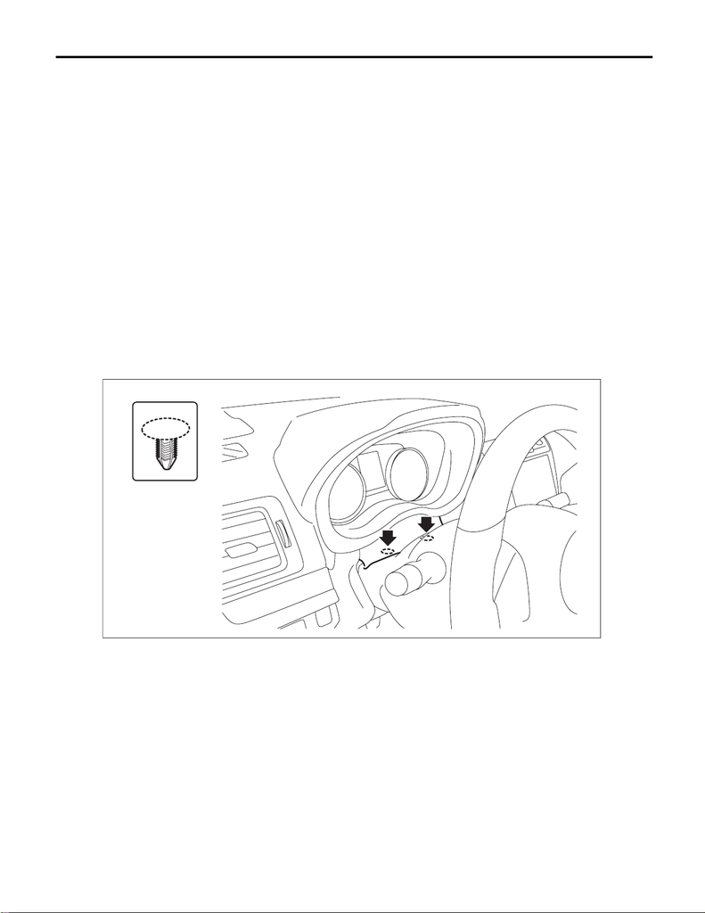

Steering Angle Sensor

VEHICLE DYNAMICS CONTROL (VDC)

8. Steering Angle Sensor

A: REMOVAL

CAUTION:

• If the steering wheel and steering angle sensor are removed, perform “VDC sensor midpoint set-

ting mode” of the VDC. <Ref. to VDC-16, VDC SENSOR MIDPOINT SETTING MODE, ADJUSTMENT,

VDC Control Module and Hydraulic Control Unit (VDCCM&H/U).>

• Before performing service on the airbag module, always refer to “CAUTION” of “General Descrip-

tion” in “AIRBAG SYSTEM” section. <Ref. to AB-9, CAUTION, General Description.>

• Always use the steering wheel puller for removal to avoid deforming the steering wheel.

• If the steering wheel has been removed, make sure that the steering roll connector is not turned

from the original position.

1) Position the front wheels straight ahead.

2) Disconnect the ground cable from battery and wait for at least 60 seconds before starting work. <Ref. to

NT-5, BATTERY, NOTE, Note.>

NOTE:

For models other than STI model, disconnect the ground terminal from battery sensor.

3) Remove the driver’s airbag module. <Ref. to AB-33, REMOVAL, Driver’s Airbag Module.>

4) Remove the steering wheel. <Ref. to PS-16, REMOVAL, Steering Wheel.>

5) Remove the cover assembly - column.

(1) Remove the clip, and remove the cover - column from the cover assembly - column UPR.

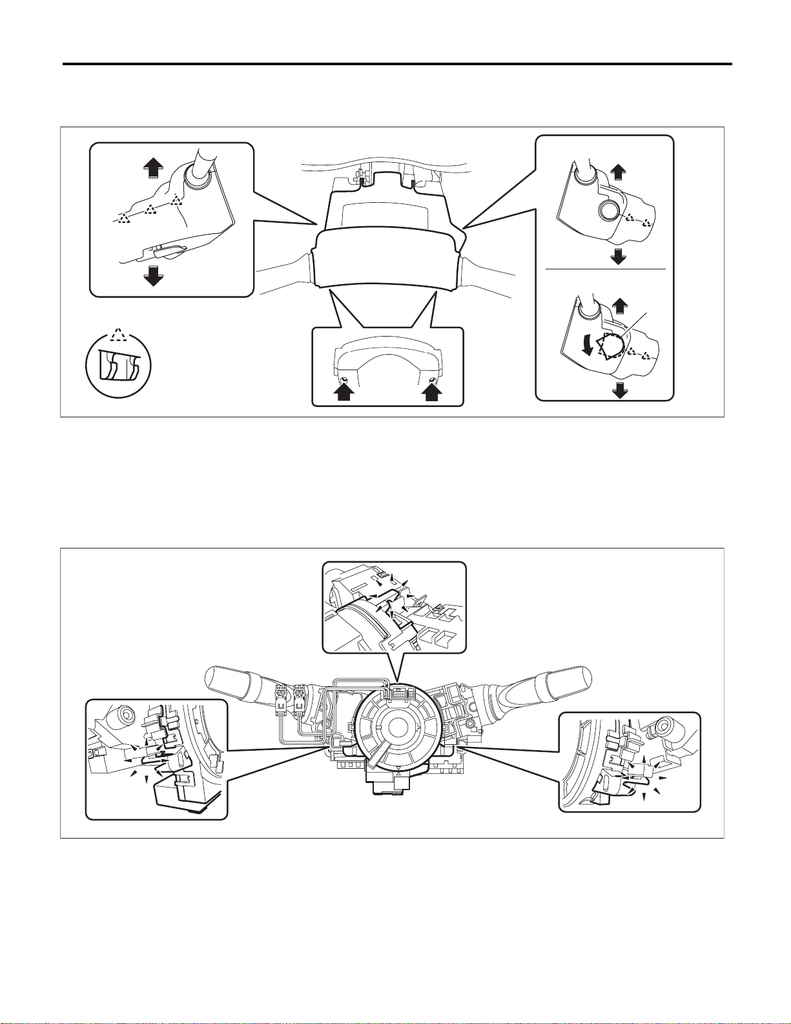

Steering Angle Sensor

VEHICLE DYNAMICS CONTROL (VDC)

(2) Remove the cap - key cylinder (a). (Model with keyless access)

(3) Release the screw and claw, and remove the cover assembly - column UPR and the cover assembly

- column LWR.

6) Remove the steering roll connector.

CAUTION:

Make sure that the steering roll connector is not turned from the original position.

(1) Disconnect the connector under the steering roll connector.

(2) Release the claws and remove the steering roll connector.

A Model without keyless access B Model with keyless access

PS-01384

A

B

(a)

AB-02914

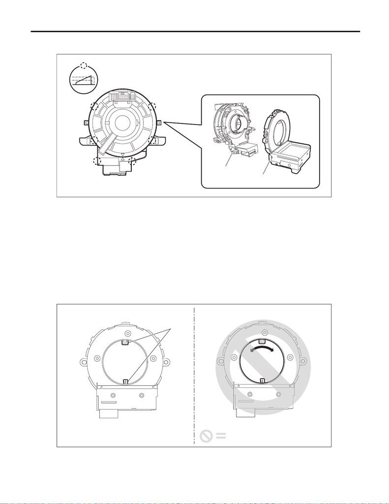

Steering Angle Sensor

VEHICLE DYNAMICS CONTROL (VDC)

7) Remove the steering angle sensor.

(1) Release the claws and remove the steering angle sensor (b) from the steering roll connector (a).

B: INSTALLATION

CAUTION:

• When removing, installing or replacing the VDCCM&H/U, VDCCM&H/U bracket, steering wheel or

steering angle sensor (steering roll connector), perform “VDC sensor midpoint setting mode” of the

VDC. <Ref. to VDC-16, VDC SENSOR MIDPOINT SETTING MODE, ADJUSTMENT, VDC Control Mod-

ule and Hydraulic Control Unit (VDCCM&H/U).>

• Before performing service on the airbag module, always refer to “CAUTION” of “General Descrip-

tion” in “AIRBAG SYSTEM” section. <Ref. to AB-9, CAUTION, General Description.>

1) Install the steering angle sensor.

(1) Apply grease to the protrusion (a) of the new steering angle sensor.

CAUTION:

Do not rotate the steering angle sensor protrusion.

(2) Align the center of steering roll connector. <Ref. to AB-61, INSTALLATION, Roll Connector.>

(3) Align the position of the protrusion and install the steering angle sensor to the steering roll connector.

VDC00987

(a)

(b)

VDC00883

(a)

[figure not shown]

Steering Angle Sensor

VEHICLE DYNAMICS CONTROL (VDC)

2) Install the cover assembly - column.

3) Install the steering wheel.

Tightening torque:

Steering wheel: 39 N·m (4.0 kgf-m, 28.8 ft-lb)

Clearance:

Between cover assembly - column and steering wheel: 4 — 6 mm (0.16 — 0.24 in)

4) Install the driver’s airbag module. <Ref. to AB-34, INSTALLATION, Driver’s Airbag Module.>

5) Connect the battery ground terminal. <Ref. to NT-5, BATTERY, NOTE, Note.>

NOTE:

For models other than STI model, connect the ground terminal to battery sensor.

6) Perform the neutral position setting of the steering angle sensor. <Ref. to VDC-16, VDC SENSOR MID-

POINT SETTING MODE, ADJUSTMENT, VDC Control Module and Hydraulic Control Unit (VDCCM&H/U).>